# SIG16 ATAC: differential accessibility across ligand contrasts

EYW

2026-09-26

```r
suppressPackageStartupMessages({
  library(tidyverse)
  library(DESeq2)
  library(ggrepel)
  library(patchwork)
})
knitr::opts_chunk$set(echo = TRUE)

source("../../functions/r_custom/plotting_fxns.R")
theme_set(theme_Publication())

set.seed(1)
options(ggrepel.max.overlaps = Inf)

idr <- 0.05
job.name <- paste0("idr-", idr, "/")

OUT_DIR  <- file.path("../../analysis_outs", "deseq2-merged-reps", job.name)
PLOT_DIR <- file.path("../../analysis_outs", "plots", "deseq2-merged-reps", job.name)

padj.cutoff <- 0.05
lfc.cutoff  <- log2(1.5)

# peaks further than this from a TSS are treated as unassigned to a gene
dist.cutoff <- 50000
# number of peaks labelled per volcano, taken from each of three sort orders
label.n <- 5

volcano.colors <- c(significant_neg  = "#800000FF", significant_pos = "#155F83FF",
                    significant_weak = "#767676FF", not_significant = "#767676FF")
```

# Goal

Extract the DESeq2 contrasts of interest from the `~ mouse + ligand1 + ligand2 + ligand1:ligand2` fit built in `01_deseq2_qc.Rmd`, and draw the per-contrast plot set (MA plot, volcano on raw and adjusted p, and per-peak normalized count plots). Volcanoes are not written per contrast: they are assembled with `patchwork` into two multi-panel figures at the top of `PLOT_DIR` (`volcano-unshrunken-all.pdf`, `volcano-fdr-unshrunken-all.pdf`).

Three kinds of contrast are pulled from the same fit — each single ligand against untreated, the pure interaction term, and each combination against untreated:

| mode | question | DESeq2 term | n |
| --- | --- | --- | --- |
| 1 | effect of `ligand1` alone (ligand2 = none) | `name = ligand1_L1_vs_none` | 3 |
| 3 | effect of TNF alone (ligand1 = none) | `name = ligand2_TNF_vs_none` | 1 |
| 5 | pure interaction term | `name = ligand1L1.ligand2TNF` | 3 |
| 6 | combined condition (`ligand1` + TNF) vs untreated | `contrast = ligand1_L1_vs_none + ligand2_TNF_vs_none + ligand1L1.ligand2TNF` | 3 |

Ten contrasts in all. Mode numbering is kept from the external collaborator’s `ATAC-analysis/SIG16_ATAC/1-deseq.R`, which also pulled the two conditional simple effects (`ligand1` given TNF, and TNF given `ligand1`); those are dropped here because nothing downstream consumes them — `03_interaction_classification.Rmd` reads modes 1/3/5/6 and `04_motif_enrichment.Rmd` reads modes 1/3 plus the interaction classification.

Because mode 6 is a sum of coefficients it is requested with a `list()` contrast, which DESeq2 evaluates as an unshrunken Wald test on the summed effect; modes 1/3/5 come straight off `resultsNames(dds)`. All results are unshrunken throughout (matching the collaborator’s `-unshrunken` file suffixes).

Mode 6 is the combined-condition effect ($b_1 + b_2 + b_{int}$, i.e. `{ligand1}_TNF` vs `none_none`). It is what `03_interaction_classification.Rmd` uses as `lfc_condition` / `adj_pval_condition`, the gate that decides whether a peak responds to the combination at all — matching the joint-condition GLM that SIG13 fits alongside its interaction model.

# Import

```r
dds <- readRDS(file.path(OUT_DIR, "deseq2_dataset.rds"))
md  <- readRDS(file.path(OUT_DIR, "metadata.rds"))

annot <- read.csv(file.path("../../analysis_outs/chipseeker", job.name,
                            "all.peakatlas/annotation.tsv"), sep = "\t")
pal <- readRDS("../../analysis_outs/plots/palette.rds")

resultsNames(dds)
```

```
##  [1] "Intercept"              "mouse_2_vs_1"           "mouse_3_vs_1"
##  [4] "ligand1_IL4_vs_none"    "ligand1_IL6_vs_none"    "ligand1_TGFb_vs_none"
##  [7] "ligand2_TNF_vs_none"    "ligand1IL4.ligand2TNF"  "ligand1IL6.ligand2TNF"
## [10] "ligand1TGFb.ligand2TNF"
```

# Contrast table

```r
ligand2 <- "TNF"
ligand1s <- c("IL4", "IL6", "TGFb")

make_jobs <- function(l1, l2 = "TNF") {
  itxn <- paste0("ligand1", l1, ".ligand2", l2)
  list(
    # mode 1: ligand1 vs none, when ligand2 = none
    list(kind = "name",
         result.name = paste0("ligand1_", l1, "_vs_none"),
         up.group = l1, down.group = "none",
         sample.conditions = c("none_none", paste0(l1, "_none"))),
    # mode 5: pure interaction term
    list(kind = "name",
         result.name = itxn,
         up.group = "synergistic", down.group = "antagonistic",
         sample.conditions = c("none_none", paste0(l1, "_none"),
                               paste0(l1, "_", l2), paste0("none_", l2))),
    # mode 6: combined condition (ligand1 + ligand2) vs untreated == b1 + b2 + b_int
    list(kind = "contrast",
         result.name = paste0("condition_", l1, "_", l2, "_vs_none_none"),
         contrast = list(c(paste0("ligand1_", l1, "_vs_none"),
                           paste0("ligand2_", l2, "_vs_none"),
                           itxn)),
         up.group = paste0(l1, "_", l2), down.group = "none_none",
         sample.conditions = c("none_none", paste0(l1, "_", l2)))
  )
}

jobs <- c(
  # mode 3: TNF vs none, when ligand1 = none (shared across all ligand1)
  list(list(kind = "name",
            result.name = paste0("ligand2_", ligand2, "_vs_none"),
            up.group = ligand2, down.group = "none",
            sample.conditions = c("none_none", paste0("none_", ligand2)))),
  unlist(lapply(ligand1s, make_jobs), recursive = FALSE)
)

# output subdirectory per job, keyed on how the contrast was requested
jobs <- lapply(jobs, function(job) {
  job$pref2 <- paste0(if (job$kind == "contrast") "contrast-" else "name-",
                      job$result.name, "/")
  job
})
names(jobs) <- vapply(jobs, function(j) j$result.name, character(1))

tibble(contrast = names(jobs),
       kind = vapply(jobs, function(j) j$kind, character(1)),
       samples = vapply(jobs, function(j) paste(j$sample.conditions, collapse = ", "),
                        character(1)))
```

```
## # A tibble: 10 × 3
##    contrast                        kind     samples
##    <chr>                           <chr>    <chr>
##  1 ligand2_TNF_vs_none             name     none_none, none_TNF
##  2 ligand1_IL4_vs_none             name     none_none, IL4_none
##  3 ligand1IL4.ligand2TNF           name     none_none, IL4_none, IL4_TNF, none_…
##  4 condition_IL4_TNF_vs_none_none  contrast none_none, IL4_TNF
##  5 ligand1_IL6_vs_none             name     none_none, IL6_none
##  6 ligand1IL6.ligand2TNF           name     none_none, IL6_none, IL6_TNF, none_…
##  7 condition_IL6_TNF_vs_none_none  contrast none_none, IL6_TNF
##  8 ligand1_TGFb_vs_none            name     none_none, TGFb_none
##  9 ligand1TGFb.ligand2TNF          name     none_none, TGFb_none, TGFb_TNF, non…
## 10 condition_TGFb_TNF_vs_none_none contrast none_none, TGFb_TNF
```

# Per-contrast analysis

```r
run_contrast <- function(job, save.results = TRUE) {
  dir.create(file.path(PLOT_DIR, job$pref2), recursive = TRUE, showWarnings = FALSE)
  dir.create(file.path(OUT_DIR, job$pref2), recursive = TRUE, showWarnings = FALSE)

  res.table.unshrunken <- if (job$kind == "contrast") {
    results(dds, contrast = job$contrast, alpha = padj.cutoff)
  } else {
    results(dds, name = job$result.name, alpha = padj.cutoff)
  }
  # Result table: annotate with nearest gene, drop untested peaks (padj = NA), and
  # carry the -log10 p columns the volcano is drawn on. Rownames are kept alongside
  # the `feature` column because the CSV export and plotCounts() both key off them.
  res.tb <- res.table.unshrunken %>%
    as.data.frame() %>%
    rownames_to_column("feature") %>%
    left_join(annot %>% dplyr::select(feature = name, distanceToTSS, geneSymbol),
              by = "feature") %>%
    relocate(feature, .after = geneSymbol) %>%
    filter(!is.na(padj)) %>%
    mutate(geneSymbol = ifelse(abs(distanceToTSS) > dist.cutoff, "", geneSymbol),
           mlog10Pval = -log10(pvalue + 1e-200),
           mlog10Padj = -log10(padj + 1e-200)) %>%
    arrange(desc(mlog10Pval)) %>%
    mutate(peak = feature) %>%
    column_to_rownames("peak")

  samples <- rownames(md[md$condition %in% job$sample.conditions, ])

  # Significant peaks, labelled by direction. This is the set everything is counted
  # from, and it is exactly the gate `03_interaction_classification.Rmd` applies to the
  # interaction term (`sig_int`), so the per-contrast tallies below agree with the
  # interaction-class counts there.
  sig <- res.tb %>%
    filter(abs(log2FoldChange) > lfc.cutoff, padj < padj.cutoff) %>%
    mutate(cluster = ifelse(log2FoldChange > 0, job$up.group, job$down.group)) %>%
    arrange(log2FoldChange)

  # Peaks to draw count plots for: one per gene, with mitochondrial and ribosomal genes
  # dropped. Distal peaks all carry geneSymbol == "" and would collapse into a single
  # representative, so they are excluded from the labelling set rather than deduplicated.
  # Never used for counting — see `sig`.
  markers <- sig %>%
    filter(geneSymbol != "",
           !grepl("(^MT-)|(^RPS)|(^RPL)|(^MRPL)|(^MRPS)", toupper(geneSymbol))) %>%
    group_by(geneSymbol) %>%
    slice_max(abs(log2FoldChange), n = 1, with_ties = FALSE) %>%
    ungroup() %>%
    arrange(log2FoldChange)

  # Volcano table: significance group per peak, plus the labels — the top `label.n`
  # by FDR, by most positive LFC, and by most negative LFC.
  volcano.tb <- res.tb %>%
    mutate(group = case_when(padj > padj.cutoff              ~ "not_significant",
                             log2FoldChange >=  lfc.cutoff   ~ "significant_pos",
                             log2FoldChange <= -lfc.cutoff   ~ "significant_neg",
                             TRUE                            ~ "significant_weak"),
           symbol = ifelse(abs(distanceToTSS) <= dist.cutoff & padj <= padj.cutoff,
                           geneSymbol, ""))

  labelled <- c(volcano.tb %>% arrange(padj) %>% head(label.n) %>% pull(feature),
                volcano.tb %>% arrange(desc(log2FoldChange)) %>% head(label.n) %>% pull(feature),
                volcano.tb %>% arrange(log2FoldChange) %>% head(label.n) %>% pull(feature))
  volcano.tb <- volcano.tb %>%
    mutate(genelabels = ifelse(feature %in% labelled, symbol, ""))

  # shared layers, so the raw-p and FDR volcanoes differ only in their y aesthetic
  volcano.layers <- list(
    geom_vline(xintercept = c(-lfc.cutoff, lfc.cutoff), color = "lightgrey"),
    geom_point(aes(colour = group), show.legend = FALSE),
    geom_text_repel(aes(label = genelabels)),
    scale_color_manual(values = volcano.colors, guide = "none"),
    labs(title = job$result.name, x = "log2 fold change"),
    theme(legend.position = "none",
          plot.title = element_text(hjust = 0.5),
          axis.title = element_text(face = "bold")))

  volcano.p <- ggplot(volcano.tb, aes(x = log2FoldChange, y = mlog10Pval)) +
    volcano.layers + ylab("-log10 p-value")

  volcano.fdr.p <- ggplot(volcano.tb, aes(x = log2FoldChange, y = mlog10Padj)) +
    volcano.layers + ylab("-log10 p.adj") +
    geom_hline(yintercept = -log10(padj.cutoff), color = "lightgrey")

  if (save.results) {
    write.csv(md, file.path(OUT_DIR, job$pref2, "metadata.csv"), quote = FALSE)
    write.csv(res.tb, file.path(OUT_DIR, job$pref2, "unshrunken-res.table.csv"), quote = FALSE)
    saveRDS(res.tb, file.path(OUT_DIR, job$pref2, "unshrunken-res.table.rds"))

    pdf(file.path(PLOT_DIR, job$pref2, "ma-plot-unshrunken.pdf"))
    plotMA(res.table.unshrunken, main = job$result.name, cex = 0.5)
    invisible(dev.off())
  }

  list(job = job, res = res.table.unshrunken, res.tb = res.tb, samples = samples,
       sig = sig, markers = markers,
       volcano.p = volcano.p, volcano.fdr.p = volcano.fdr.p)
}
```

Per-peak normalized count plots for the top 20 gained and top 20 lost peaks. These are written to multi-page PDFs rather than shown inline.

```r
save_count_plots <- function(r, direction = c("pos", "neg"), n.max = 20) {
  direction <- match.arg(direction)
  job <- r$job
  plot.markers <- if (direction == "pos") {
    r$markers %>% arrange(desc(log2FoldChange)) %>% subset(log2FoldChange > 0)
  } else {
    r$markers %>% arrange(log2FoldChange) %>% subset(log2FoldChange < 0)
  }
  if (nrow(plot.markers) == 0) return(invisible(NULL))

  n.plots <- min(nrow(plot.markers), n.max)
  count.plots <- lapply(seq_len(n.plots), function(i) {
    gene   <- plot.markers$feature[i]
    symbol <- plot.markers$geneSymbol[i]
    counts_data <- plotCounts(dds, gene = gene, intgroup = c("ligand1", "ligand2"),
                              returnData = TRUE)
    counts_data$interaction_group <- interaction(counts_data$ligand1, counts_data$ligand2)
    counts_data <- counts_data[r$samples, ]

    ggplot(counts_data, aes(x = interaction_group, y = count,
                            color = ligand1, shape = ligand2)) +
      geom_jitter(size = 3, height = 0, width = 0.2) +
      scale_y_log10() +
      scale_color_manual(values = pal$ligand1) +
      labs(title = paste0(gene, " - ", symbol), x = "Group", y = "Normalized Count")
  })

  pdf(file.path(PLOT_DIR, job$pref2, paste0("counts-unshrunken-", direction, ".pdf")),
      width = 6, height = 4)
  for (p in count.plots) print(p)
  invisible(dev.off())
}
```

```r
results_list <- list()

for (nm in names(jobs)) {
  cat("\n\n## ", nm, "\n\n", sep = "")
  r <- run_contrast(jobs[[nm]])
  results_list[[nm]] <- r

  n.up   <- sum(r$sig$cluster == r$job$up.group)
  n.down <- sum(r$sig$cluster == r$job$down.group)
  cat("`", r$job$up.group, "` (up): ", n.up,
      " peaks; `", r$job$down.group, "` (down): ", n.down,
      " peaks at padj < ", padj.cutoff, ", |LFC| > log2(1.5).\n\n", sep = "")

  plotMA(r$res, main = nm, cex = 0.5)

  save_count_plots(r, "pos")
  save_count_plots(r, "neg")
}
```

## ligand2_TNF_vs_none

`TNF` (up): 3861 peaks; `none` (down): 1266 peaks at padj < 0.05, |LFC| > log2(1.5).

## ligand1_IL4_vs_none

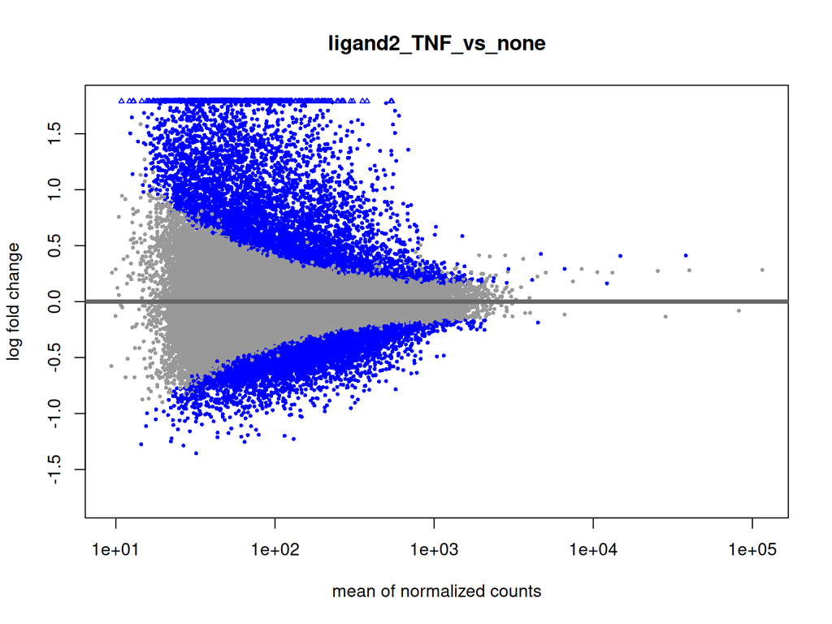

`IL4` (up): 3294 peaks; `none` (down): 2830 peaks at padj < 0.05, |LFC| > log2(1.5).

## ligand1IL4.ligand2TNF

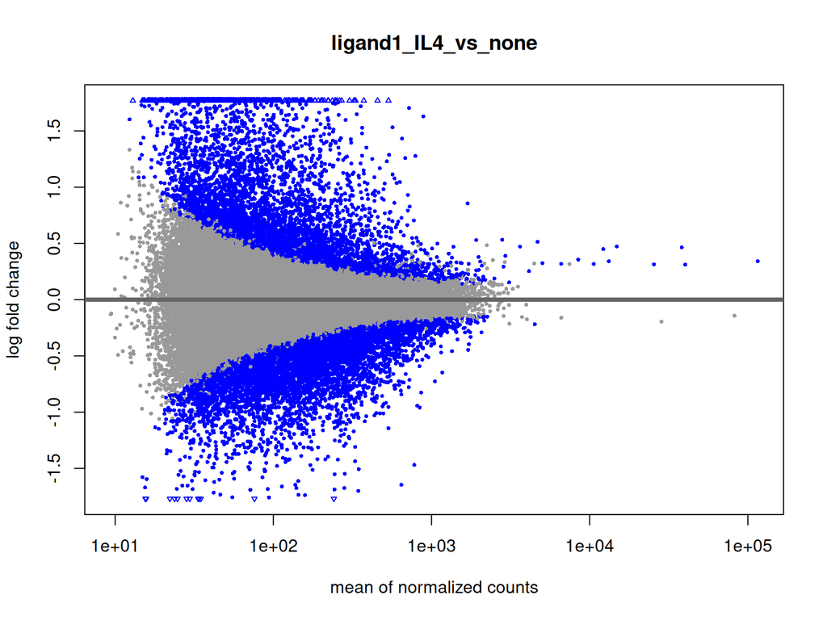

`synergistic` (up): 116 peaks; `antagonistic` (down): 533 peaks at padj < 0.05, |LFC| > log2(1.5).

## condition_IL4_TNF_vs_none_none

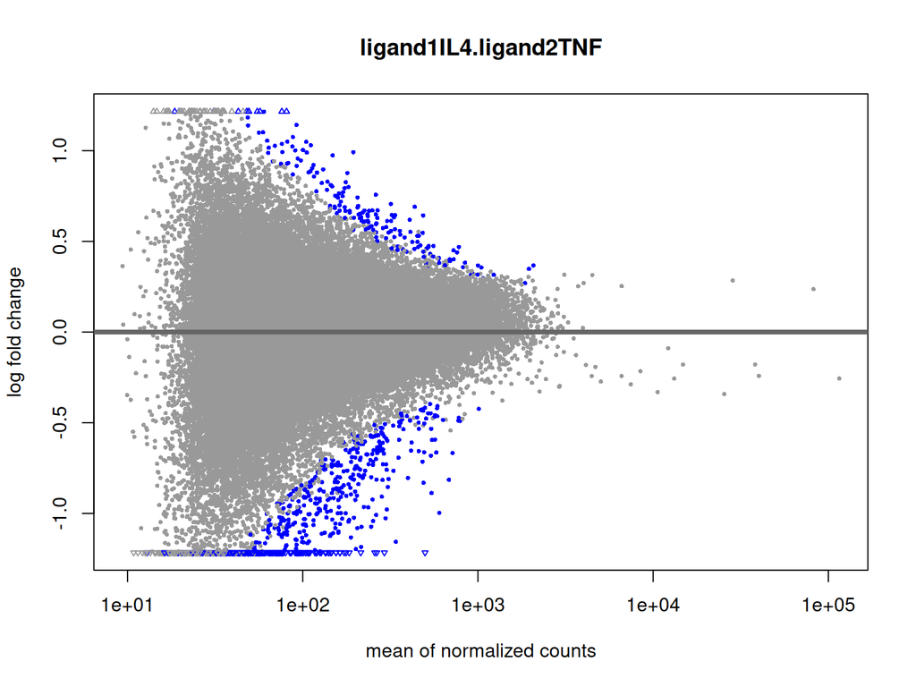

`IL4_TNF` (up): 6046 peaks; `none_none` (down): 4731 peaks at padj < 0.05, |LFC| > log2(1.5).

## ligand1_IL6_vs_none

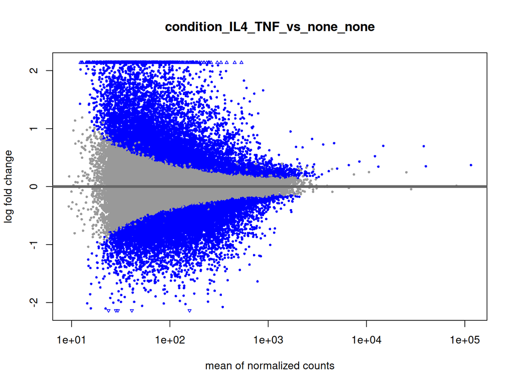

`IL6` (up): 507 peaks; `none` (down): 169 peaks at padj < 0.05, |LFC| > log2(1.5).

## ligand1IL6.ligand2TNF

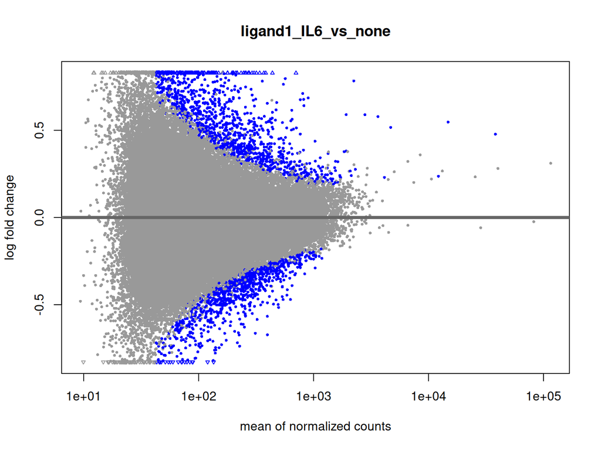

`synergistic` (up): 8 peaks; `antagonistic` (down): 9 peaks at padj < 0.05, |LFC| > log2(1.5).

## condition_IL6_TNF_vs_none_none

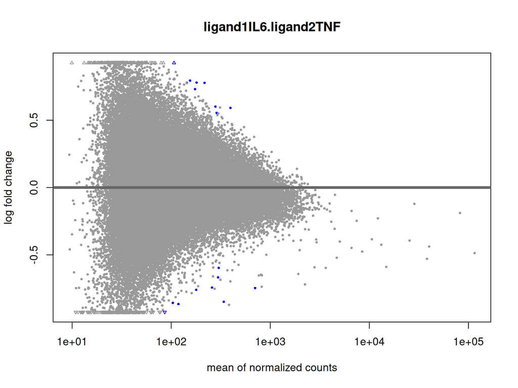

`IL6_TNF` (up): 5653 peaks; `none_none` (down): 2169 peaks at padj < 0.05, |LFC| > log2(1.5).

## ligand1_TGFb_vs_none

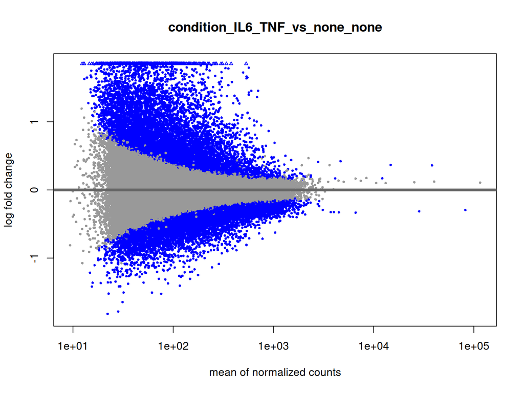

`TGFb` (up): 1230 peaks; `none` (down): 71 peaks at padj < 0.05, |LFC| > log2(1.5).

## ligand1TGFb.ligand2TNF

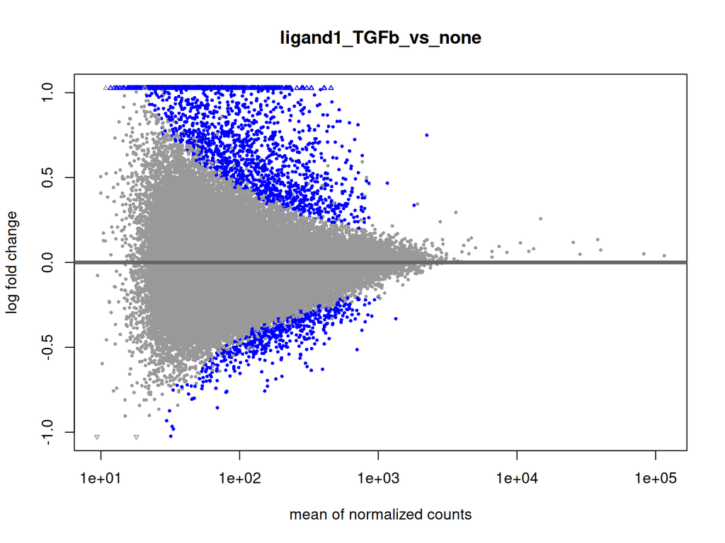

`synergistic` (up): 55 peaks; `antagonistic` (down): 0 peaks at padj < 0.05, |LFC| > log2(1.5).

## condition_TGFb_TNF_vs_none_none

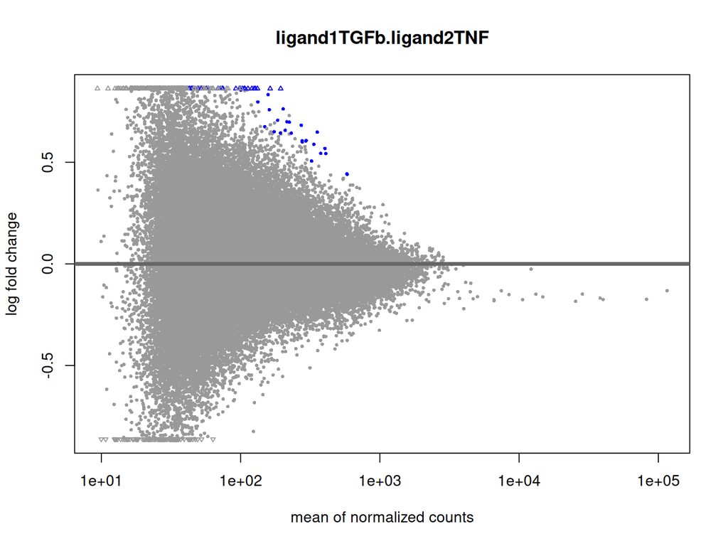

`TGFb_TNF` (up): 6033 peaks; `none_none` (down): 2446 peaks at padj < 0.05, |LFC| > log2(1.5).

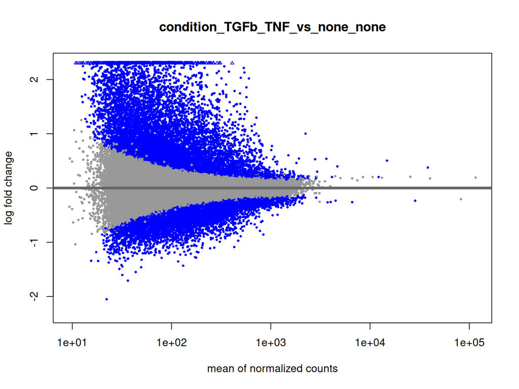

# Combined volcano panels

All 10 contrasts on one page, raw p on top figure and FDR on the second, assembled with `patchwork` (4 columns). Written to `PLOT_DIR` rather than the per-contrast directories.

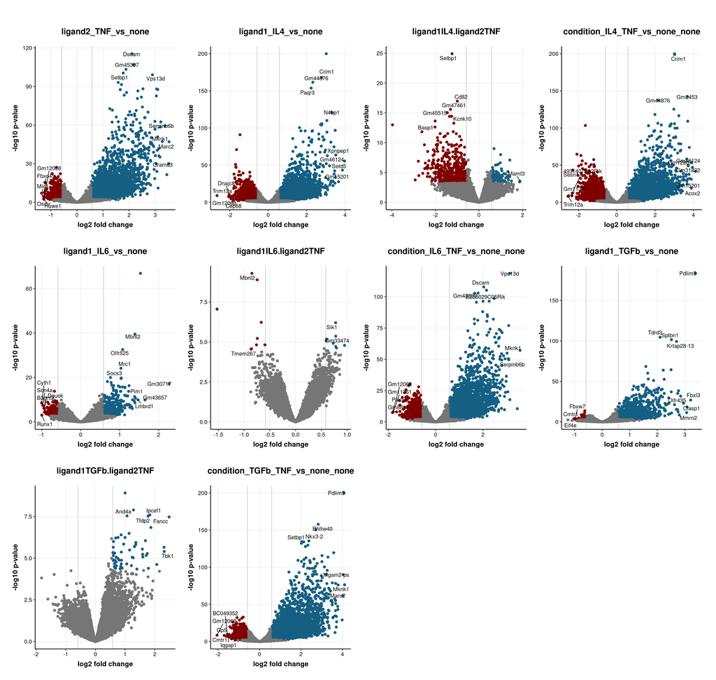

```r
volcano_panel <- function(which.p) {
  ps <- lapply(results_list, function(r) {
    r[[which.p]] + theme(legend.position = "none") +
      labs(title = r$job$result.name)
  })
  wrap_plots(ps, ncol = 4)
}

volcano.all.p     <- volcano_panel("volcano.p")
volcano.fdr.all.p <- volcano_panel("volcano.fdr.p")

ggsave(file.path(PLOT_DIR, "volcano-unshrunken-all.pdf"),
       volcano.all.p, width = 20, height = 19, limitsize = FALSE)
ggsave(file.path(PLOT_DIR, "volcano-fdr-unshrunken-all.pdf"),
       volcano.fdr.all.p, width = 20, height = 19, limitsize = FALSE)

volcano.all.p
```

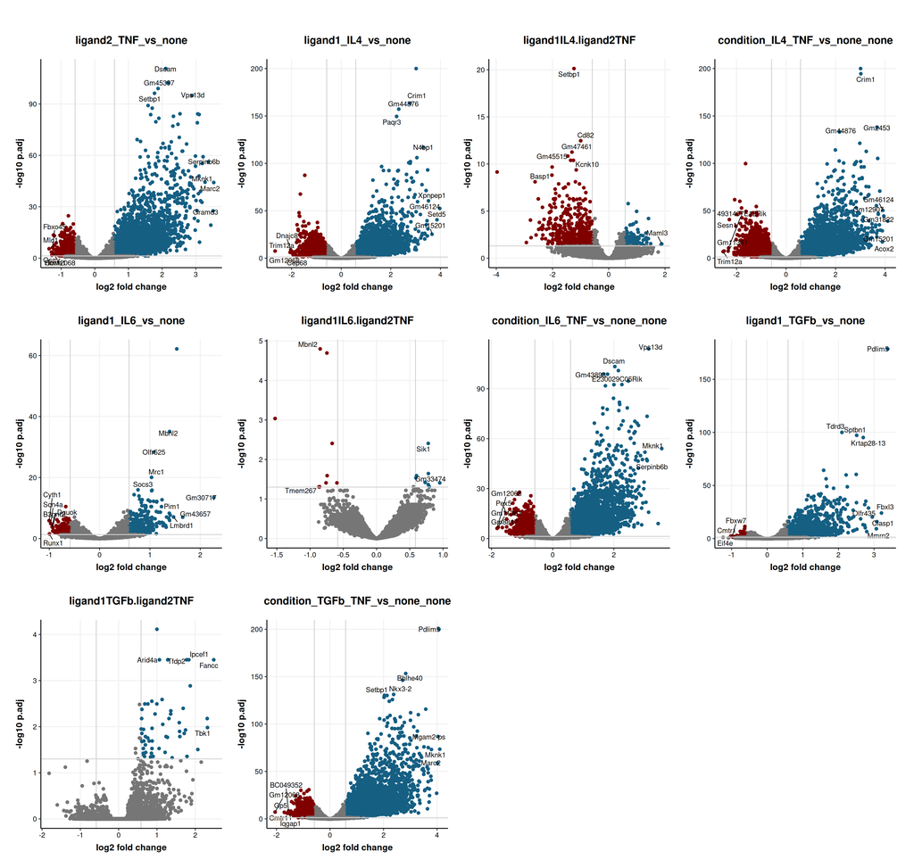

```r
volcano.fdr.all.p
```

Heatmaps are not drawn here. All accessibility heatmaps live in `03_interaction_classification.Rmd`, where rows can be faceted by interaction class — see the “Heatmaps” section there.

# Summary

```r
map_dfr(results_list, function(r) {
  tibble(contrast = r$job$result.name,
         tested_peaks = nrow(r$res.tb),
         up = sum(r$sig$cluster == r$job$up.group),
         down = sum(r$sig$cluster == r$job$down.group),
         up_group = r$job$up.group,
         down_group = r$job$down.group)
})
```

```
## # A tibble: 10 × 6
##    contrast                        tested_peaks    up  down up_group  down_group
##    <chr>                                  <int> <int> <int> <chr>     <chr>
##  1 ligand2_TNF_vs_none                    63218  3861  1266 TNF       none
##  2 ligand1_IL4_vs_none                    63218  3294  2830 IL4       none
##  3 ligand1IL4.ligand2TNF                  63218   116   533 synergis… antagonis…
##  4 condition_IL4_TNF_vs_none_none         63218  6046  4731 IL4_TNF   none_none
##  5 ligand1_IL6_vs_none                    50961   507   169 IL6       none
##  6 ligand1IL6.ligand2TNF                  31351     8     9 synergis… antagonis…
##  7 condition_IL6_TNF_vs_none_none         63218  5653  2169 IL6_TNF   none_none
##  8 ligand1_TGFb_vs_none                   63218  1230    71 TGFb      none
##  9 ligand1TGFb.ligand2TNF                 63218    55     0 synergis… antagonis…
## 10 condition_TGFb_TNF_vs_none_none        63218  6033  2446 TGFb_TNF  none_none
```